# Problem: Predicting Credit Card Fraud

## Introduction to business scenario

You work for a multinational bank. There has been a significant increase in the number of customers experiencing credit card fraud over the last few months. A major news outlet even recently published a story about the credit card fraud you and other banks are experiencing.

As a response to this situation, you have been tasked to solve part of this problem by leveraging machine learning to identify fraudulent credit card transactions before they have a larger impact on your company. You have been given access to a dataset of past credit card transactions, which you can use to train a machine learning model to predict if transactions are fraudulent or not.

## About this dataset

The dataset contains transactions made by credit cards in September 2013 by European cardholders. This dataset presents transactions that occurred over the course of two days and includes examples of both fraudulent and legitimate transactions.

### Features

The dataset contains over 30 numerical features, most of which have undergone principal component analysis (PCA) transformations because of personal privacy issues with the data. The only features that have not been transformed with PCA are 'Time' and 'Amount'. The feature 'Time' contains the seconds elapsed between each transaction and the first transaction in the dataset. The feature 'Amount' is the transaction amount. 'Class' is the response or target variable, and it takes a value of '1' in cases of fraud and '0' otherwise.

Features: `V1, V2, ... V28`: Principal components obtained with PCA

Non-PCA features:

- `Time`: Seconds elapsed between each transaction and the first transaction in the dataset, $T_x - t_0$
- `Amount`: Transaction amount; this feature can be used for example-dependent cost-sensitive learning
- `Class`: Target variable where `Fraud = 1` and `Not Fraud = 0`

### Dataset attributions

Website: https://www.openml.org/d/1597

Twitter: https://twitter.com/dalpozz/status/645542397569593344

Authors: Andrea Dal Pozzolo, Olivier Caelen, and Gianluca Bontempi Source: Credit card fraud detection - June 25, 2015 Official citation: Andrea Dal Pozzolo, Olivier Caelen, Reid A. Johnson, and Gianluca Bontempi. Calibrating Probability with Undersampling for Unbalanced Classification. In Symposium on Computational Intelligence and Data Mining (CIDM), IEEE, 2015.

The dataset has been collected and analyzed during a research collaboration of Worldline and the Machine Learning Group (mlg.ulb.ac.be) of ULB (Université Libre de Bruxelles) on big data mining and fraud detection. More details on current and past projects on related topics are available on http://mlg.ulb.ac.be/BruFence and http://mlg.ulb.ac.be/ARTML.

# Step 1: Problem formulation and data collection

Start this project off by writing a few sentences below that summarize the business problem and the business goal you're trying to achieve in this scenario. Include a business metric you would like your team to aspire toward. With that information defined, clearly write out the machine learning problem statement. Finally, add a comment or two about the type of machine learning this represents.

#### Project presentation: Include a summary of these details in your project presentations.

### Read through a business scenario and:

### 1. Determine if and why ML is an appropriate solution to deploy.

ML is appropriate because of the scale, variety and speed required. There are potentially thousands of transactions happening that needs to be identified correctly and take actions near real time.

### 2. Formulate the business problem, success metrics, and desired ML output.

Over the last few months, there has been a significant uptick in the number of customers experiencing credit card fraud and it is impacting trust values and global business. To reduce further any larger impact, every transaction needs to identify as fraudulent or not correctly. Our aim is to use ML model to detect 100% of the fraudulent transactions. We also need to ensure that we have very less incorrect fraud classifications.

Recall will be the best metric to understand ML model performance. As we are more concerned about fraud transaction if it is incorrectly classified (False Negatives), Hence higher recall value will tell us about model is correctly classifying fraud transactions.

### 3. Identify the type of ML problem you’re dealing with.

We should use supervised machine learning algorithm with binary classification. We should use supervised machine learning algorithm with binary classification. This can be solve using Supervised Binary classification algorithm like logistic regression, KNN, SVM, decision tree, random forest, etc.

### 4. Analyze the appropriateness of the data you’re working with.

The dataset contains over 30 numerical features, most of which have undergone principal component analysis (PCA) transformations because of personal privacy issues with the data. The only features that have not been transformed with PCA are 'Time' and 'Amount'. The feature 'Time' contains the seconds elapsed between each transaction and the first transaction in the dataset. The feature 'Amount' is the transaction amount. 'Class' is the response or target variable, and it takes a value of '1' in cases of fraud and '0' otherwise.

Features: V1, V2, ... V28: Principal components obtained with PCA

we have to focus on below features only

Non-PCA features:

- Time: Seconds elapsed between each transaction and the first transaction in the dataset, 𝑇𝑥−𝑡0
- Amount: Transaction amount; this feature can be used for example-dependent cost-sensitive learning
- Class: Target variable where Fraud = 1 and Not Fraud = 0

Data is appropriate as it is label properly.

### Setup

Now that we have decided where to focus our energy, let's set things up so you can start working on solving the problem.

**Note:** This notebook was created and tested on an `ml.m4.xlarge` notebook instance.

```python
# Import various Python libraries

import numpy as np
import pandas as pd
import matplotlib.pyplot as plt
import seaborn as sns
import time

sns.set()
%matplotlib inline
```

```python
# Install imblearn
!pip uninstall scikit-learn -y
!pip install imbalanced-learn==0.7.0
!pip install imblearn
```

```
Found existing installation: scikit-learn 0.24.2
Uninstalling scikit-learn-0.24.2:
  Successfully uninstalled scikit-learn-0.24.2
```

### Get the dataset

```python
df = pd.read_csv(r'C:\Users\ankush.ramrao.yadav\Downloads\fraud.csv')
```

# Step 2: Data preprocessing and visualization

In this data preprocessing phase, you should take the opportunity to explore and visualize your data to better understand it. First, import the necessary libraries and read the data into a Pandas dataframe. After that, explore your data. Look for the shape of the dataset and explore your columns and the types of columns you're working with (numerical, categorical). Consider performing basic statistics on the features to get a sense of feature means and ranges. Take a close look at your target column and determine its distribution.

### Specific questions to consider

1. What can you deduce from the basic statistics you ran on the features?
2. What can you deduce from the distributions of the target classes?
3. Is there anything else you deduced from exploring the data?

Read the CSV data into a Pandas dataframe. You can use the built-in Python `read_csv` function ([documentation](https://pandas.pydata.org/pandas-docs/stable/reference/api/pandas.read_csv.html)).

```python
df.head()
```

|  | Time | V1 | V2 | V3 | V4 | V5 | V6 | V7 | V8 | V9 | ... | V21 | V22 | V23 | V24 | V25 | V26 | V27 | V28 | Amount | Class |
| --- | --- | --- | --- | --- | --- | --- | --- | --- | --- | --- | --- | --- | --- | --- | --- | --- | --- | --- | --- | --- | --- |
| 0 | 0.0 | -1.359807 | -0.072781 | 2.536347 | 1.378155 | -0.338321 | 0.462388 | 0.239599 | 0.098698 | 0.363787 | ... | -0.018307 | 0.277838 | -0.110474 | 0.066928 | 0.128539 | -0.189115 | 0.133558 | -0.021053 | 149.62 | '0' |
| 1 | 0.0 | 1.191857 | 0.266151 | 0.166480 | 0.448154 | 0.060018 | -0.082361 | -0.078803 | 0.085102 | -0.255425 | ... | -0.225775 | -0.638672 | 0.101288 | -0.339846 | 0.167170 | 0.125895 | -0.008983 | 0.014724 | 2.69 | '0' |
| 2 | 1.0 | -1.358354 | -1.340163 | 1.773209 | 0.379780 | -0.503198 | 1.800499 | 0.791461 | 0.247676 | -1.514654 | ... | 0.247998 | 0.771679 | 0.909412 | -0.689281 | -0.327642 | -0.139097 | -0.055353 | -0.059752 | 378.66 | '0' |
| 3 | 1.0 | -0.966272 | -0.185226 | 1.792993 | -0.863291 | -0.010309 | 1.247203 | 0.237609 | 0.377436 | -1.387024 | ... | -0.108300 | 0.005274 | -0.190321 | -1.175575 | 0.647376 | -0.221929 | 0.062723 | 0.061458 | 123.50 | '0' |
| 4 | 2.0 | -1.158233 | 0.877737 | 1.548718 | 0.403034 | -0.407193 | 0.095921 | 0.592941 | -0.270533 | 0.817739 | ... | -0.009431 | 0.798278 | -0.137458 | 0.141267 | -0.206010 | 0.502292 | 0.219422 | 0.215153 | 69.99 | '0' |

5 rows × 31 columns

```python
df.shape
```

```
(284807, 31)
```

Here data set is consists of 284807 rows ans 31 columns including target

```python
# The Target class has a weird string instead of a boolean or numbers 0 and 1, so convert it to 0 and 1
mapped_class = {"'0'": 0, "'1'": 1}
df['Class'] = df['Class'].map(lambda x: mapped_class[x])
```

```python
# Check if that worked
df.head()
```

|  | Time | V1 | V2 | V3 | V4 | V5 | V6 | V7 | V8 | V9 | ... | V21 | V22 | V23 | V24 | V25 | V26 | V27 | V28 | Amount | Class |
| --- | --- | --- | --- | --- | --- | --- | --- | --- | --- | --- | --- | --- | --- | --- | --- | --- | --- | --- | --- | --- | --- |
| 0 | 0.0 | -1.359807 | -0.072781 | 2.536347 | 1.378155 | -0.338321 | 0.462388 | 0.239599 | 0.098698 | 0.363787 | ... | -0.018307 | 0.277838 | -0.110474 | 0.066928 | 0.128539 | -0.189115 | 0.133558 | -0.021053 | 149.62 | 0 |
| 1 | 0.0 | 1.191857 | 0.266151 | 0.166480 | 0.448154 | 0.060018 | -0.082361 | -0.078803 | 0.085102 | -0.255425 | ... | -0.225775 | -0.638672 | 0.101288 | -0.339846 | 0.167170 | 0.125895 | -0.008983 | 0.014724 | 2.69 | 0 |
| 2 | 1.0 | -1.358354 | -1.340163 | 1.773209 | 0.379780 | -0.503198 | 1.800499 | 0.791461 | 0.247676 | -1.514654 | ... | 0.247998 | 0.771679 | 0.909412 | -0.689281 | -0.327642 | -0.139097 | -0.055353 | -0.059752 | 378.66 | 0 |
| 3 | 1.0 | -0.966272 | -0.185226 | 1.792993 | -0.863291 | -0.010309 | 1.247203 | 0.237609 | 0.377436 | -1.387024 | ... | -0.108300 | 0.005274 | -0.190321 | -1.175575 | 0.647376 | -0.221929 | 0.062723 | 0.061458 | 123.50 | 0 |
| 4 | 2.0 | -1.158233 | 0.877737 | 1.548718 | 0.403034 | -0.407193 | 0.095921 | 0.592941 | -0.270533 | 0.817739 | ... | -0.009431 | 0.798278 | -0.137458 | 0.141267 | -0.206010 | 0.502292 | 0.219422 | 0.215153 | 69.99 | 0 |

5 rows × 31 columns

```python
df.columns
```

```
Index(['Time', 'V1', 'V2', 'V3', 'V4', 'V5', 'V6', 'V7', 'V8', 'V9', 'V10',
       'V11', 'V12', 'V13', 'V14', 'V15', 'V16', 'V17', 'V18', 'V19', 'V20',
       'V21', 'V22', 'V23', 'V24', 'V25', 'V26', 'V27', 'V28', 'Amount',
       'Class'],
      dtype='object')
```

here we have total 28(V1-V28) anonymous coulmns and 2(Amount, Time) non-anonymized columns with one target (class)

```python
# get more information about the columns
df.info()
```

```
<class 'pandas.core.frame.DataFrame'>
RangeIndex: 284807 entries, 0 to 284806
Data columns (total 31 columns):
 #   Column  Non-Null Count   Dtype
---  ------  --------------   -----
 0   Time    284807 non-null  float64
 1   V1      284807 non-null  float64
 2   V2      284807 non-null  float64
 3   V3      284807 non-null  float64
 4   V4      284807 non-null  float64
 5   V5      284807 non-null  float64
 6   V6      284807 non-null  float64
 7   V7      284807 non-null  float64
 8   V8      284807 non-null  float64
 9   V9      284807 non-null  float64
```

[output cut: 23 more lines]

**Question**: Perform basic statistics using the Pandas library and `Describe` function. What is the mean and standard deviation for the `amount` feature? What can you deduce from those numbers?

```python
df.describe()
```

|  | Time | V1 | V2 | V3 | V4 | V5 | V6 | V7 | V8 | V9 | ... | V21 | V22 | V23 | V24 | V25 | V26 | V27 | V28 | Amount | Class |
| --- | --- | --- | --- | --- | --- | --- | --- | --- | --- | --- | --- | --- | --- | --- | --- | --- | --- | --- | --- | --- | --- |
| count | 284807.000000 | 2.848070e+05 | 2.848070e+05 | 2.848070e+05 | 2.848070e+05 | 2.848070e+05 | 2.848070e+05 | 2.848070e+05 | 2.848070e+05 | 2.848070e+05 | ... | 2.848070e+05 | 2.848070e+05 | 2.848070e+05 | 2.848070e+05 | 2.848070e+05 | 2.848070e+05 | 2.848070e+05 | 2.848070e+05 | 284807.000000 | 284807.000000 |
| mean | 94813.859575 | 3.918649e-15 | 5.682686e-16 | -8.761736e-15 | 2.811118e-15 | -1.552103e-15 | 2.040130e-15 | -1.698953e-15 | -1.893285e-16 | -3.147640e-15 | ... | 1.473120e-16 | 8.042109e-16 | 5.282512e-16 | 4.456271e-15 | 1.426896e-15 | 1.701640e-15 | -3.662252e-16 | -1.217809e-16 | 88.349619 | 0.001727 |
| std | 47488.145955 | 1.958696e+00 | 1.651309e+00 | 1.516255e+00 | 1.415869e+00 | 1.380247e+00 | 1.332271e+00 | 1.237094e+00 | 1.194353e+00 | 1.098632e+00 | ... | 7.345240e-01 | 7.257016e-01 | 6.244603e-01 | 6.056471e-01 | 5.212781e-01 | 4.822270e-01 | 4.036325e-01 | 3.300833e-01 | 250.120109 | 0.041527 |
| min | 0.000000 | -5.640751e+01 | -7.271573e+01 | -4.832559e+01 | -5.683171e+00 | -1.137433e+02 | -2.616051e+01 | -4.355724e+01 | -7.321672e+01 | -1.343407e+01 | ... | -3.483038e+01 | -1.093314e+01 | -4.480774e+01 | -2.836627e+00 | -1.029540e+01 | -2.604551e+00 | -2.256568e+01 | -1.543008e+01 | 0.000000 | 0.000000 |
| 25% | 54201.500000 | -9.203734e-01 | -5.985499e-01 | -8.903648e-01 | -8.486401e-01 | -6.915971e-01 | -7.682956e-01 | -5.540759e-01 | -2.086297e-01 | -6.430976e-01 | ... | -2.283949e-01 | -5.423504e-01 | -1.618463e-01 | -3.545861e-01 | -3.171451e-01 | -3.269839e-01 | -7.083953e-02 | -5.295979e-02 | 5.600000 | 0.000000 |
| 50% | 84692.000000 | 1.810880e-02 | 6.548556e-02 | 1.798463e-01 | -1.984653e-02 | -5.433583e-02 | -2.741871e-01 | 4.010308e-02 | 2.235804e-02 | -5.142873e-02 | ... | -2.945017e-02 | 6.781943e-03 | -1.119293e-02 | 4.097606e-02 | 1.659350e-02 | -5.213911e-02 | 1.342146e-03 | 1.124383e-02 | 22.000000 | 0.000000 |
| 75% | 139320.500000 | 1.315642e+00 | 8.037239e-01 | 1.027196e+00 | 7.433413e-01 | 6.119264e-01 | 3.985649e-01 | 5.704361e-01 | 3.273459e-01 | 5.971390e-01 | ... | 1.863772e-01 | 5.285536e-01 | 1.476421e-01 | 4.395266e-01 | 3.507156e-01 | 2.409522e-01 | 9.104512e-02 | 7.827995e-02 | 77.165000 | 0.000000 |
| max | 172792.000000 | 2.454930e+00 | 2.205773e+01 | 9.382558e+00 | 1.687534e+01 | 3.480167e+01 | 7.330163e+01 | 1.205895e+02 | 2.000721e+01 | 1.559499e+01 | ... | 2.720284e+01 | 1.050309e+01 | 2.252841e+01 | 4.584549e+00 | 7.519589e+00 | 3.517346e+00 | 3.161220e+01 | 3.384781e+01 | 25691.160000 | 1.000000 |

8 rows × 31 columns

For feature "Amount" Mean is 88.35 dollars and standard deviation is 250.12 dollars. Max value of amount is going more than 25K dollars

```python
# Get descriptive stats about the data points which are fraudulent transactions
print("Fraud Statistics")

avg_amt = df[df['Class']== 1]['Amount'].mean()
std_dev = df[df['Class']==1]['Amount'].std()
max_amt = df[df['Class']==1]['Amount'].max()

print(f"The average amount is {avg_amt}")
print(f"The std deviation for amount is {std_dev}")
print(f"The max amount is {max_amt}")
```

```
Fraud Statistics
The average amount is 122.21132113821133
The std deviation for amount is 256.68328829771207
The max amount is 2125.87
```

```python
# Check if dataset is balanced for thr target variable Class as we are dealing with Supervised Classification problem.
df['Class'].value_counts()
```

```
0    284315
1       492
Name: Class, dtype: int64
```

```python
# Ratio of classes Fraud and Non-Fraud
fraud_ratio = df['Class'].value_counts()[0] / df['Class'].count()
non_fraud_ratio = df['Class'].value_counts()[1] / df['Class'].count()
print (f"We have {fraud_ratio*100} percentage of data which is not fraud and we have {non_fraud_ratio*100} percentage as fraud data")
```

```
We have 99.82725143693798 percentage of data which is not fraud and we have 0.1727485630620034 percentage as fraud data
```

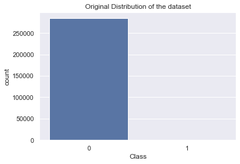

```python
sns.countplot(df['Class'])
plt.title('Original Distribution of the dataset')
```

Its is very clear that we have imbalanced data. If we use this dataframe as the base for our predictive models and analysis we might get a lot of errors and our algorithms will probably overfit since it will "assume" that most transactions are not fraud.

## Visualize your data

If you haven't done so in the above, you can use the space below to further visualize some of your data. Look specifically at the distribution of features like `Amount` and `Time`, and also calculate the linear correlations between the features in the dataset.

### Specific questions to consider

1. After looking at the distributions of features like `Amount` and `Time`, to what extend might those features help your model? Is there anything you can deduce from those distributions that might be helpful in better understanding your data?
2. Do the distributions of features like `Amount` and `Time` differ when you are looking only at data that is labeled as fraud?
3. Are there any features in your dataset that are strongly correlated? If so, what would be your next steps?

```python
# get numerical summary of features TIME and AMOUNT
df.loc[:, ['Time', 'Amount']].describe()
```

|  | Time | Amount |
| --- | --- | --- |
| count | 284807.000000 | 284807.000000 |
| mean | 94813.859575 | 88.349619 |
| std | 47488.145955 | 250.120109 |
| min | 0.000000 | 0.000000 |
| 25% | 54201.500000 | 5.600000 |
| 50% | 84692.000000 | 22.000000 |
| 75% | 139320.500000 | 77.165000 |
| max | 172792.000000 | 25691.160000 |

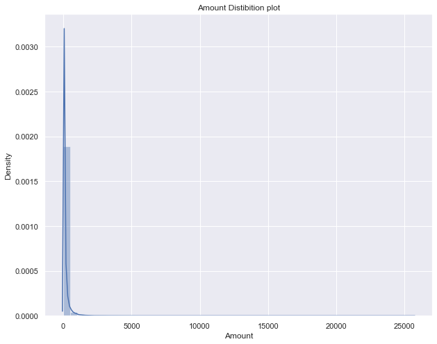

```python
#Lets get distibution of the feature Amount
plt.figure(figsize=(10,8))
plt.title("Amount Distibition plot")
sns.distplot(df['Amount'])
```

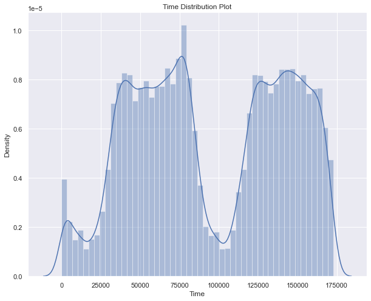

```python
# Get Distribution of the feature Time
plt.figure(figsize = (10,8))
plt.title ("Time Distribution Plot")
sns.distplot(df['Time'])
```

we can say that this data set includes all transactions recorded over the course of two days. This indicates that approximately 28 hours after the first transaction there was a significant drop in the volume of transactions. here we can assume that the drop in volume occurred during the night.

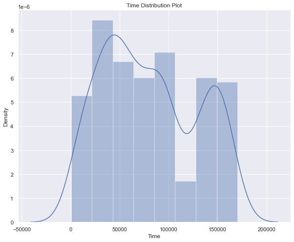

```python
# Get Distribution of the feature Time when transaction is fraudulent
plt.figure(figsize = (10,8))
plt.title ("Time Distribution Plot")
sns.distplot(df[df['Class'] == 1]['Time'])
```

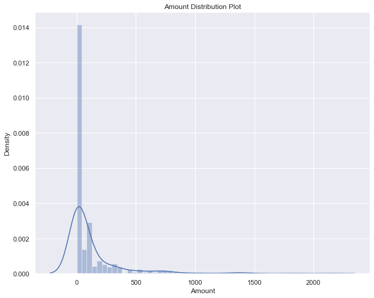

```python
# Get Distribution of the feature Amount when transaction is fraudulent
plt.figure(figsize=(10,8))
plt.title ("Amount Distribution Plot")
sns.distplot(df[df['Class']==1]['Amount'])
```

You can see for the smaller subset of the features that we used, there is a way to differentiate the fraud and not fraud, but it's not easy to separate it based on any one feature.

Now, let's look at how these features interact with each other. Use the Pandas `<dataframe>.corr()` function to calculate the linear correlations between all the features of the dataset. It is always easier to visualize the correlation. Plot the correlation using the Seaborn heatmap (`sns.heatmap`) function with the `annot` flag set to `True`.

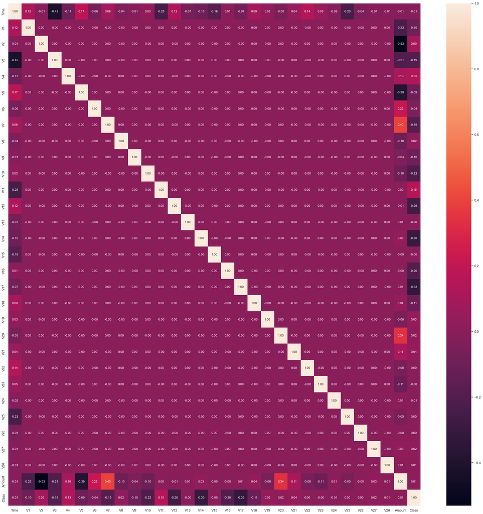

```python
# Get correlation between the features if any feature having high correlation we can remove that
plt.figure(figsize = (30,30))
correlation_matrix = df.corr()
sns.heatmap(correlation_matrix, annot=True,fmt=".2f")
```

We could see there is no correlation between the features so we dont have to remove any feature here. Highest negative correlation between Amount and V2 is 0.53 but still that can be ingnore.

- Scale Time and Amount features

Amount and Time features are having very bigger values that values might impact the model training. So we need to scale it.

```python
from sklearn.preprocessing import StandardScaler
time_scaler = StandardScaler()
amount_scaler = StandardScaler()
```

```python
# Scaling the time feature
scaled_time = time_scaler.fit_transform(df[['Time']])
flat_list1 = [item for sublist in scaled_time.tolist() for item in sublist]
scaled_time = pd.Series(flat_list1)
```

```python
# Scaling the Amount feature
scaled_amount = amount_scaler.fit_transform(df[['Amount']])
flat_list1 = [item for sublist in scaled_amount.tolist() for item in sublist]
scaled_amount = pd.Series(flat_list1)
```

```python
#concatenating newly created columns with original df
df = pd.concat([df, scaled_amount.rename('scaled_amount'), scaled_time.rename('scaled_time')], axis=1)
df.sample(5)
```

|  | Time | V1 | V2 | V3 | V4 | V5 | V6 | V7 | V8 | V9 | ... | V23 | V24 | V25 | V26 | V27 | V28 | Amount | Class | scaled_amount | scaled_time |
| --- | --- | --- | --- | --- | --- | --- | --- | --- | --- | --- | --- | --- | --- | --- | --- | --- | --- | --- | --- | --- | --- |
| 170630 | 120280.0 | -5.181385 | 5.082231 | -1.891530 | -2.400167 | 1.280996 | 1.238303 | 0.304316 | -8.012326 | 5.213663 | ... | 0.620594 | -0.305627 | 0.218692 | -0.342109 | 1.275166 | -0.483553 | 0.77 | 0 | -0.350151 | 0.536264 |
| 205515 | 135786.0 | 1.754427 | -0.922034 | -1.680276 | 0.169265 | 0.710024 | 1.588781 | -0.306001 | 0.331130 | -1.047492 | ... | 0.285595 | -1.048778 | -0.383398 | -0.853862 | 0.049375 | -0.034318 | 139.60 | 0 | 0.204903 | 0.862788 |
| 170102 | 120016.0 | -0.254285 | 0.022598 | -1.205879 | -3.205432 | 3.185703 | 3.021180 | 0.461720 | 0.570733 | -1.402025 | ... | -0.189200 | 0.596602 | 0.061300 | -0.395335 | -0.061841 | -0.073239 | 25.00 | 0 | -0.253277 | 0.530705 |
| 73443 | 55136.0 | 0.024012 | -1.696554 | -0.651639 | 1.492240 | -0.388605 | 0.304212 | 0.904147 | -0.077453 | -0.159338 | ... | -0.698057 | -0.253726 | 0.559429 | -0.307541 | -0.091771 | 0.100606 | 602.34 | 0 | 2.054978 | -0.835533 |
| 222280 | 142912.0 | -4.479923 | -2.982295 | -3.236432 | 0.228750 | -2.624150 | 2.501965 | 2.401306 | 0.993340 | 0.362913 | ... | 1.834743 | -1.568934 | -2.251270 | -0.047380 | 0.743416 | -0.394839 | 738.63 | 0 | 2.599877 | 1.012847 |

5 rows × 33 columns

```python
# Removed the unnecessary columns Time and Amount from the data
df.drop(columns= ['Time', 'Amount'], axis = 1, inplace = True)
df.sample(5)
```

|  | V1 | V2 | V3 | V4 | V5 | V6 | V7 | V8 | V9 | V10 | ... | V22 | V23 | V24 | V25 | V26 | V27 | V28 | Class | scaled_amount | scaled_time |
| --- | --- | --- | --- | --- | --- | --- | --- | --- | --- | --- | --- | --- | --- | --- | --- | --- | --- | --- | --- | --- | --- |
| 38368 | -1.139438 | 0.458993 | 2.091212 | -0.321100 | 0.643809 | -0.928815 | 0.492983 | 0.023952 | -0.634718 | -0.842481 | ... | 0.066091 | -0.151452 | 0.427087 | 0.323837 | 0.234419 | -0.011880 | 0.067492 | 0 | -0.333279 | -1.167617 |
| 171721 | 2.000883 | -0.648503 | -0.286084 | -0.005754 | -0.567123 | 0.563099 | -1.143511 | 0.370695 | 1.323210 | 0.180861 | ... | 0.109414 | 0.285220 | 0.086529 | -0.558886 | 0.471810 | -0.027325 | -0.051102 | 0 | -0.349231 | 0.546919 |
| 129064 | -0.368888 | 0.851415 | 0.216788 | -0.078064 | 0.111044 | -0.097103 | 0.325409 | 0.484047 | -0.368376 | -0.620369 | ... | 0.157613 | -0.016817 | -0.773305 | -0.232451 | 0.375814 | -0.116410 | -0.043239 | 0 | -0.196025 | -0.334334 |
| 7477 | -1.653100 | -0.286792 | 2.140757 | 1.079250 | 0.060787 | 2.183577 | -1.400927 | 1.218666 | 1.150061 | -0.846682 | ... | 0.221466 | 0.224388 | -0.973625 | -0.550600 | 1.396200 | -0.124762 | -0.038471 | 0 | -0.247240 | -1.782508 |
| 88439 | 1.276089 | 0.178602 | -0.435948 | 0.128762 | 0.702271 | 0.712898 | -0.124131 | 0.193931 | -0.104274 | -0.157455 | ... | -0.930704 | -0.073793 | -1.751985 | 0.338835 | 0.213188 | -0.014617 | 0.001000 | 0 | -0.313289 | -0.688044 |

5 rows × 31 columns

# Model training and evaluation

```python
from sklearn.model_selection import train_test_split

df_feature = df.drop(['Class'], axis=1)
df_class = df['Class']

train_feature, test_feature, train_class, test_class = train_test_split(df_feature, df_class, test_size=0.25)
```

```python
# See you data split
print(f"Length of train_features is: {train_feature.shape}")
print(f"Length of train_class is: {train_class.shape}")
print(f"Length of test_feature is: {test_feature.shape}")
print(f"Length of test_class is: {test_class.shape}")
```

```
Length of train_features is: (213605, 30)
Length of train_class is: (213605,)
Length of test_feature is: (71202, 30)
Length of test_class is: (71202,)
```

### Model training

```python
pip install xgboost
```

```python
from sklearn.model_selection import KFold
from sklearn.model_selection import cross_val_score
from sklearn.metrics import roc_auc_score
from sklearn.metrics import classification_report
from sklearn.metrics import confusion_matrix
from sklearn.linear_model import LogisticRegression
from sklearn.discriminant_analysis import LinearDiscriminantAnalysis
from sklearn.neighbors import KNeighborsClassifier
from sklearn.tree import DecisionTreeClassifier
from sklearn.svm import SVC
from xgboost import XGBClassifier
from sklearn.ensemble import RandomForestClassifier
```

```python
##Spot-Checking Algorithms

models = []

models.append(('LR', LogisticRegression()))
models.append(('LDA', LinearDiscriminantAnalysis()))
models.append(('KNN', KNeighborsClassifier()))
models.append(('CART', DecisionTreeClassifier()))
models.append(('SVM', SVC()))
models.append(('XGB', XGBClassifier()))
models.append(('RF', RandomForestClassifier()))

#testing models

results = []
names = []

for name, model in models:
    kfold = KFold(n_splits=10, random_state=42, shuffle=True)
    cv_results = cross_val_score(model, train_feature, train_class, cv=kfold, scoring='roc_auc')
    results.append(cv_results)
    names.append(name)
    msg = '%s: %f (%f)' % (name, cv_results.mean(), cv_results.std())
    print(msg)
```

```
LR: 0.975603 (0.020077)
LDA: 0.982984 (0.011853)
KNN: 0.924996 (0.031400)
CART: 0.880346 (0.038753)
SVM: 0.938926 (0.039247)
XGB: 0.982751 (0.017473)
RF: 0.944856 (0.027387)
```

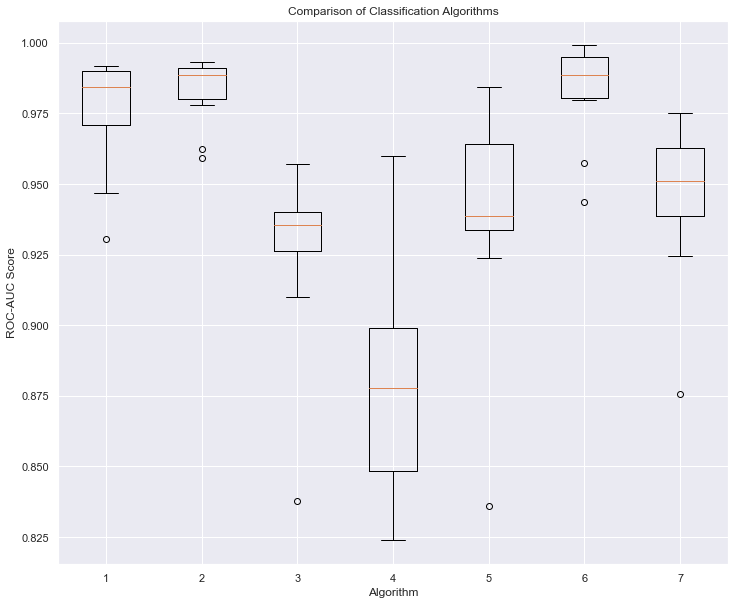

```python
#Compare Algorithms

fig = plt.figure(figsize=(12,10))
plt.title('Comparison of Classification Algorithms')
plt.xlabel('Algorithm')
plt.ylabel('ROC-AUC Score')
plt.boxplot(results)
#ax = fig.add_subplot(111)
ax.set_xticklabels(names)
plt.show()
```

## Feature Engineering

Train Model with balanced data set

The accuracy is calculated with how many examples the model got right. However, most of the examples are actually negative, so if you actually predict all examples as zero in this very imbalanced dataset, you can still get an accuracy of about 99.827%. Having an imbalanced dataset may cause some problems with algorithm performance. So it's useful to treat the imbalance in the data before you train the model.

There are two main ways to handle imbalanced datasets:

- Oversample to add more positive samples
  - Random oversampling
  - [Synthetic minority oversampling technique (SMOTE)](https://arxiv.org/abs/1106.1813)
- Undersample to reduce the negative samples
  - Random undersampling
  - Generate centroids using clustering methods

```python
#Convert train_feature back to data frame
df_train = pd.DataFrame(train_feature, columns = df.columns.drop(['Class']))
df_train['Class'] = train_class
```

```python
df_train.sample(5)
```

|  | V1 | V2 | V3 | V4 | V5 | V6 | V7 | V8 | V9 | V10 | ... | V22 | V23 | V24 | V25 | V26 | V27 | V28 | scaled_amount | scaled_time | Class |
| --- | --- | --- | --- | --- | --- | --- | --- | --- | --- | --- | --- | --- | --- | --- | --- | --- | --- | --- | --- | --- | --- |
| 189018 | 2.013066 | -0.072423 | -1.238716 | 0.562889 | -0.249662 | -1.622368 | 0.362104 | -0.379182 | 0.760433 | -0.038672 | ... | -0.206189 | 0.228948 | 0.422841 | 0.004885 | -0.442206 | -0.033418 | -0.053642 | -0.293018 | 0.703759 | 0 |
| 6250 | -0.303522 | 0.321466 | 1.844147 | -0.345545 | -0.921119 | -0.432680 | -0.069181 | -0.138086 | 0.329046 | 0.016581 | ... | -0.016212 | -0.182145 | 0.321759 | -0.038172 | -0.163742 | -0.037349 | 0.084004 | -0.234486 | -1.842334 | 0 |
| 220570 | 2.024130 | -0.240221 | -0.674434 | 0.218264 | -0.072491 | -0.112333 | -0.323924 | -0.133309 | 1.071143 | -0.223070 | ... | -0.414798 | 0.206553 | -0.997250 | -0.234277 | -0.567841 | 0.042463 | -0.034137 | -0.253317 | 0.998380 | 0 |
| 202377 | 2.156353 | -0.937086 | -3.570045 | -1.986558 | 2.384654 | 2.707242 | -0.296166 | 0.463805 | -1.138657 | 0.924162 | ... | 0.867001 | -0.076744 | 0.769406 | 0.466718 | 0.094736 | -0.069968 | -0.078066 | -0.083758 | 0.831496 | 0 |
| 190316 | 1.650126 | -2.045412 | -1.123322 | -2.330907 | -1.536712 | -1.103377 | -0.338683 | -0.329628 | 1.452063 | -0.732558 | ... | -1.398606 | 0.201768 | -0.138667 | -0.440472 | -1.272578 | 0.051882 | 0.017195 | 0.761197 | 0.715299 | 0 |

5 rows × 31 columns

```python
fraud_df = df_train[df_train['Class'] == 1]

non_fraud_df = df_train[df_train['Class'] == 0].sample(n=len(fraud_df), random_state=235)

balanced_df = pd.concat([fraud_df, non_fraud_df], ignore_index=True, sort=False)

balanced_df.head()
```

|  | V1 | V2 | V3 | V4 | V5 | V6 | V7 | V8 | V9 | V10 | ... | V22 | V23 | V24 | V25 | V26 | V27 | V28 | scaled_amount | scaled_time | Class |
| --- | --- | --- | --- | --- | --- | --- | --- | --- | --- | --- | --- | --- | --- | --- | --- | --- | --- | --- | --- | --- | --- |
| 0 | 0.326007 | 1.286638 | -2.007181 | 2.419675 | -1.532902 | -1.432803 | -2.459530 | 0.617738 | -1.125861 | -3.236784 | ... | 0.169776 | -0.174357 | 0.308061 | 0.710996 | -0.231030 | 0.580495 | 0.300984 | -0.328161 | -0.740078 | 1 |
| 1 | -21.885434 | 12.930505 | -24.098872 | 6.203314 | -16.466099 | -4.459842 | -16.519836 | 14.535565 | -3.897022 | -8.650758 | ... | -1.579055 | -0.951043 | 0.134565 | 1.507110 | -0.222671 | 1.527655 | 0.453699 | 0.046539 | -1.430146 | 1 |
| 2 | 0.725646 | 2.300894 | -5.329976 | 4.007683 | -1.730411 | -1.732193 | -3.968593 | 1.063728 | -0.486097 | -4.624985 | ... | 0.109541 | 0.601045 | -0.364700 | -1.843078 | 0.351909 | 0.594550 | 0.099372 | -0.349231 | -1.836332 | 1 |
| 3 | -11.682215 | 6.332882 | -13.297109 | 7.690772 | -10.889891 | -2.792360 | -12.561783 | 7.287122 | -7.570322 | -12.835738 | ... | -1.271509 | -0.035304 | 0.615054 | 0.349024 | -0.428923 | -0.694935 | -0.818970 | 0.338719 | -1.127459 | 1 |
| 4 | -1.108478 | 3.448953 | -6.216972 | 3.021052 | -0.529901 | -2.551375 | -2.001743 | 1.092432 | -0.836098 | -4.095649 | ... | 1.144170 | 0.208559 | -0.295497 | -0.690232 | -0.364749 | 0.229327 | 0.208830 | -0.281264 | -0.057317 | 1 |

5 rows × 31 columns

```python
balanced_df.shape
```

```
(782, 31)
```

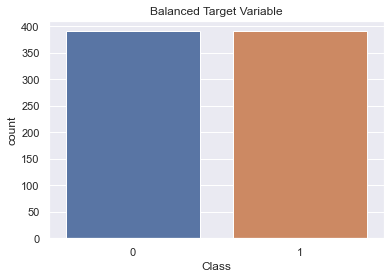

```python
sns.countplot(balanced_df['Class'])
plt.title('Balanced Target Variable')
```

```python
#  feature reduction technique like t-Distributed Stochastic Neighbor Embedding (t-SNE) on the dataset.
from sklearn.manifold import TSNE

X_embedded = TSNE(n_components=2).fit_transform(balanced_df.drop(columns = "Class"))
X_embedded.shape
```

```
(782, 2)
```